# The Daddy Quota Dividend

A Data-Driven Case for Father-Centric Parental Leave

Author

Sinyu Yang

Published

July 1, 2025

Keywords

Data Analysis, Public Policy, R, Data Visualization

# 1 Objective

For decades, parental leave policies have often been functionally synonymous with maternity leave, a dynamic that contributes to the “motherhood penalty” in women’s careers. A key indicator of this economic disparity is the persistent gender pay gap. While many countries have introduced leave policies for fathers, their effectiveness varies significantly.

This report presents a quantitative analysis of paternal leave policies across the European Union to answer a critical research question: **What structural components of a paternal leave policy correlate with higher uptake by fathers and, subsequently, with greater gender equality in the workplace?** Our central hypothesis is that a policy’s financial generosity and the inclusion of non-transferable quotas for fathers are more significant drivers of success than statutory leave length alone.

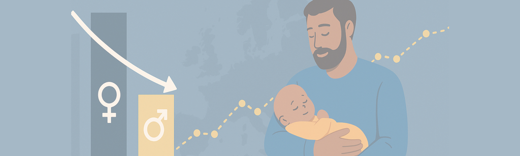

# 2 Methodology and Data Integration

A robust analysis required the construction of a multi-faceted dataset. This was an exercise in multi-source data consolidation that involved several key quantitative steps:

A robust analysis required constructing a multi-faceted dataset by consolidating data from multiple OECD and Eurostat sources, including 2023 policy reports and historical 2014 data. To address inconsistencies in the availability of gender pay gap data, a “last observation carried forward” methodology was employed, ensuring the analysis is as current as possible.

Recognizing that a simple count of leave weeks is a misleading metric , as a long leave at a low pay rate is not a viable option for most families, we developed a more insightful metric:

`Full-Rate Equivalent (FRE) Weeks`. This metric calculates the length of a leave if it were paid at 100% of previous earnings, providing a standardized measure of a policy’s true financial generosity. The FRE metric serves as a key independent variable in our analysis. The analysis then proceeded to data visualization and correlation analysis to build a narrative, with each component designed to answer a specific question.

```r
# load the tidyverse
library(tidyverse)
library(ggrepel)
library(ggplot2)
library(dplyr)
library(ggcorrplot)
library(sf) # For working with spatial data
library(rnaturalearth) # For getting map data
library(rnaturalearthdata) # The map data itself
library(ggrepel) # For labels (optional for maps, but can be useful)

# ==============================================================================
# PHASE 1: DATA ACQUISITION AND WRANGLING
# ==============================================================================
# In a real project, you would use functions like read_csv() to load data.
# Here, we simulate this by defining the data directly in data frames.

# --- 1.1: Load Baseline 2014 Data ---
raw_data <- read_csv('OECD,DF_FAMILY,+..FAM12A+FAM12B+FAM8A.csv')

mothers_leave_2014 <- raw_data %>%
  filter(IND == "FAM12A" & TIME_PERIOD == 2014) %>%
  select(Country, Mothers_Leave_Weeks_2014 = OBS_VALUE)

# Extract Fathers' Leave Weeks (FAM12B) for 2014
fathers_leave_2014 <- raw_data %>%
  filter(IND == "FAM12B" & TIME_PERIOD == 2014) %>%
  select(Country, Fathers_Leave_Weeks_2014 = OBS_VALUE)

# Extract Mothers' Employment Rate (FAM8A) for 2014
mothers_employment_2014 <- raw_data %>%
  filter(IND == "FAM8A" & TIME_PERIOD == 2014) %>%
  select(Country, Mothers_Employment_2014 = OBS_VALUE)

df_2014 <- mothers_leave_2014 %>%
  full_join(fathers_leave_2014, by = "Country") %>%
  full_join(mothers_employment_2014, by = "Country")

# --- 1.2: Transcribe 2023 Policy Data ---
# FRE = Full-Rate Equivalent weeks.
df_2023 <- read_csv('PF2_1_Parental_leave_systems(father).csv')

# --- 1.3: Transcribe Outcome Data ---
df_takeup <- read_csv('father_take_up_rate.csv') %>%
select(Country, Father_Take_Up_Rate_pct = `Father_Take_Up_Rate_pct\n`)

df_pay_gap <- read_csv('estat_sdg_05_20_filtered_en.csv') %>%
filter(TIME_PERIOD == 2023) %>%
select(Country = `Geopolitical entity (reporting)`, Gender_Pay_Gap_2023_pct = OBS_VALUE)

# --- NEW: Dynamically process the gender pay gap CSV ---
# Define the path to your Eurostat CSV file
gender_gap_file_path <- "estat_sdg_05_20_filtered_en.csv"

# Read, clean, and process the data to get the latest value for each country
df_pay_gap_latest <- read_csv(gender_gap_file_path) %>%
  # Clean up country names to ensure they match our other data sources
  mutate(geo = str_replace(`Geopolitical entity (reporting)`, " \\(.*", "")) %>% # Removes text in parentheses (e.g., for Germany)
  mutate(geo = case_when(
      `Geopolitical entity (reporting)` == "Türkiye" ~ "Turkey", # Standardize names
      TRUE ~ `Geopolitical entity (reporting)`
  )) %>%
  # Group by country to operate on each one individually
  group_by(`Geopolitical entity (reporting)`) %>%
  # Find the row with the most recent year for each country
  slice_max(order_by = TIME_PERIOD, n = 1) %>%
  # Ungroup to prevent accidental grouped operations later
  ungroup() %>%
  # Select and rename the final columns for clarity
  select(Country = `Geopolitical entity (reporting)`, Gender_Pay_Gap_2023_pct = OBS_VALUE)

# --- 1.4: Merge and Clean DataFrames using dplyr ---
# The pipe operator `%>%` passes the result of one function to the next.
df_all <- df_2023 %>%
  left_join(df_2014, by = "Country") %>%
  left_join(df_takeup, by = "Country") %>%
  left_join(df_pay_gap_latest, by = "Country") %>%
  # Replace NA values with 0 for all numeric columns
  mutate(across(where(is.numeric), ~replace_na(., 0)))

#Filter out EU countries
eu_countries <- c(
  "Austria", "Belgium", "Bulgaria", "Croatia", "Cyprus", "Czechia", "Denmark",
  "Estonia", "Finland", "France", "Germany", "Greece", "Hungary", "Ireland",
  "Italy", "Latvia", "Lithuania", "Luxembourg", "Malta", "Netherlands",
  "Poland", "Portugal", "Romania", "Slovak Republic", "Slovenia", "Spain", "Sweden"
)

df <- df_all %>%
  filter(Country %in% eu_countries)

df$Fathers_FRE_Weeks_2023 <- as.numeric(df$Fathers_FRE_Weeks_2023)

# Display the head and structure of the final dataframe
print("--- Master DataFrame Head ---")
print(head(df))
print("--- Data Structure ---")
str(df)
```

[output not shown]

# 3 Visual Analysis and Findings

## 3.1 Exhibit A: Beyond Length – What Makes a Policy Truly Generous?

The initial analysis sought to challenge the assumption that longer leave is always better. The FRE metric revealed a more nuanced reality.

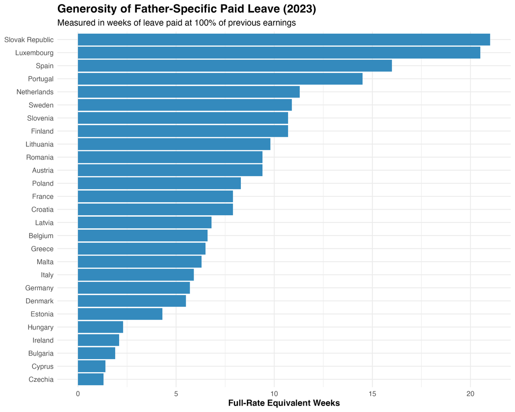

Bar Chart of Father’s Leave Generosity (2023)

```r
# ==============================================================================
# PHASE 2: EXPLORATORY DATA ANALYSIS & VISUALIZATION (using ggplot2)
# ==============================================================================

# --- 2.1: Bar Chart of Father's Leave Generosity (2023) ---
generosity_FL <- ggplot(df, aes(x = Fathers_FRE_Weeks_2023, y = reorder(Country, Fathers_FRE_Weeks_2023))) +
  geom_col(fill = "#348ABD") +
  labs(
    title = "Generosity of Father-Specific Paid Leave (2023)",
    subtitle = "Measured in weeks of leave paid at 100% of previous earnings",
    x = "Full-Rate Equivalent Weeks",
    y = "Country"
  ) +
  theme_minimal(base_size = 12) +
  theme(
    plot.title = element_text(face = "bold", size = 16),
    axis.title.x = element_text(face = "bold"),
    axis.title.y = element_blank()
  )

ggsave("Generosity of Father-Specific Paid Leave (2023).png", plot = generosity_FL, width = 10, height = 8, dpi = 300)
```

## 3.2 Exhibit B: A Decade of Reform in Paternal Leave

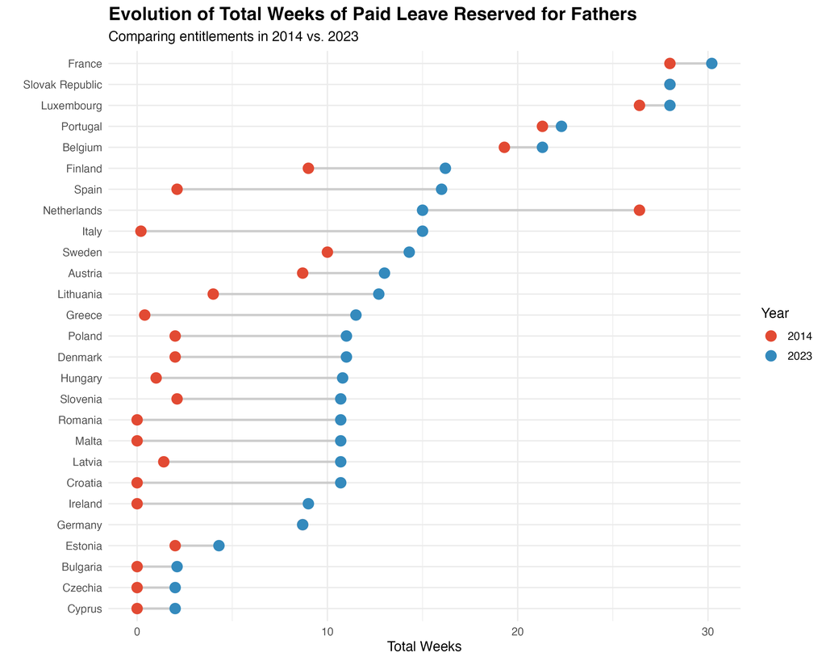

Dumbbell Chart of Policy Evolution (2014 vs. 2023)

```r
# --- 2.2: Dumbbell Chart of Policy Evolution (2014 vs. 2023) ---
df_evo <- df %>%
  filter(Fathers_Leave_Weeks_2014 > 0 | Fathers_Leave_Weeks_2023 > 0)

Policy_evo <- ggplot(df_evo, aes(y = reorder(Country, Fathers_Leave_Weeks_2023))) +
  geom_segment(aes(x = Fathers_Leave_Weeks_2014, xend = Fathers_Leave_Weeks_2023, yend = Country),
               color = "grey", size = 1, alpha = 0.7) +
  geom_point(aes(x = Fathers_Leave_Weeks_2014, color = "2014"), size = 4) +
  geom_point(aes(x = Fathers_Leave_Weeks_2023, color = "2023"), size = 4) +
  scale_color_manual(name = "Year", values = c("2014" = "#E24A33", "2023" = "#348ABD")) +
  labs(
    title = "Evolution of Total Weeks of Paid Leave Reserved for Fathers",
    subtitle = "Comparing entitlements in 2014 vs. 2023",
    x = "Total Weeks",
    y = ""
  ) +
  theme_minimal(base_size = 12) +
  theme(plot.title = element_text(face = "bold", size = 16))
ggsave("Policy Evolution (2014 vs. 2023).png", plot = Policy_evo, width = 10, height = 8, dpi = 300)
```

## 3.3 Exhibit C: The Correlation Story – Connecting Policy to Outcomes

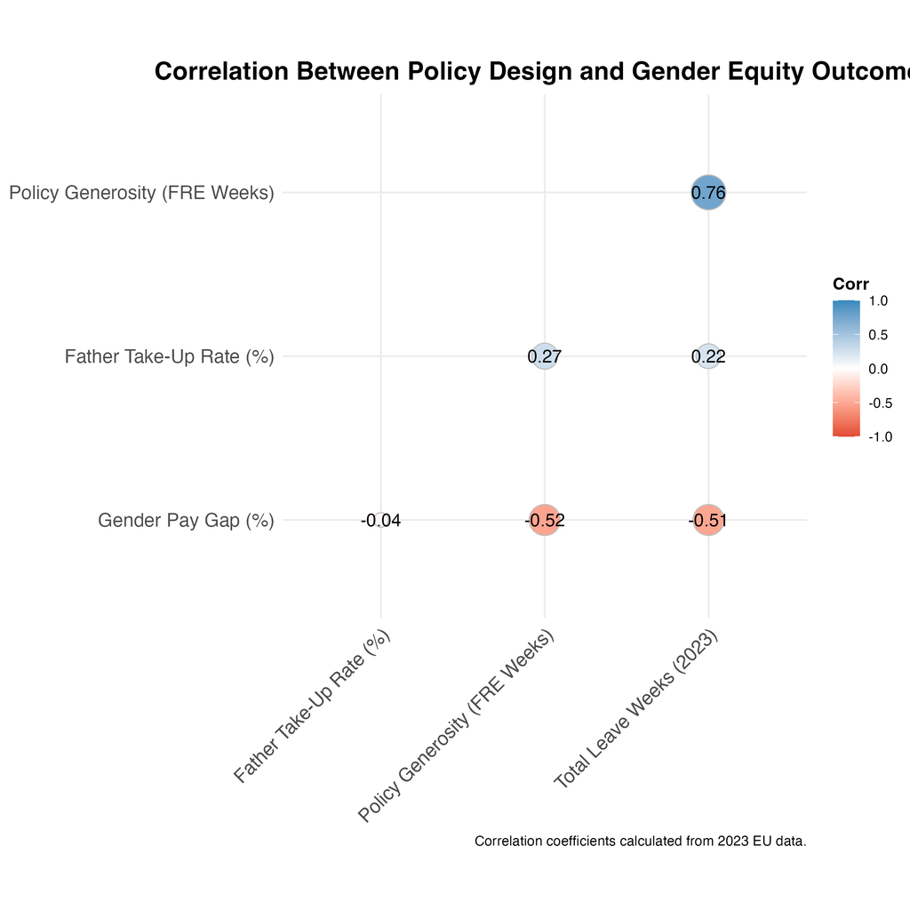

Correlation Between Policy Design and Gender Equity Outcomes

To directly test our hypothesis, we move to the correlation matrix, which quantifies the relationships between policy design and gender equity outcomes. The results are striking:

- **Policy Generosity vs. Total Leave Weeks (Correlation: 0.76)**: There is a strong positive correlation between the total weeks offered to fathers and the financial generosity (FRE Weeks) of that leave. This suggests that countries investing in longer leave periods are also, by and large, investing in making them financially viable.
- **Gender Pay Gap vs. Policy Generosity (Correlation: -0.52)**: Here we see a moderate negative correlation. As the financial generosity of paternal leave increases, the gender pay gap tends to decrease. This is a critical, data-supported link between a specific policy lever (well-paid leave for fathers) and a key measure of workplace gender equality.
- **Gender Pay Gap vs. Total Leave Weeks (Correlation: -0.51)**: A nearly identical moderate negative correlation exists between the total leave weeks available to fathers and the gender pay gap. This reinforces the finding that providing more leave time for fathers is associated with a smaller pay gap.
- **Father Take-Up Rate (%)**: The relationship between take-up rates and other variables is weaker. This is likely due to the complexity of factors influencing a father’s decision to take leave, including cultural norms and workplace support, which are not captured in this dataset. However, the negative correlation with the pay gap, though small (-0.04), still points in the hypothesized direction. This correlogram provides quantitative backing for our central argument: the design of paternal leave policies has a measurable correlation with the gender pay gap.

```r
# PHASE 2.5: CORRELATION ANALYSIS
# =================================

# First, install the ggcorrplot package if you haven't already
library(ggplot2)
library(tidyverse)
library(dplyr)
library(ggcorrplot)


# 1. Select only the numeric columns of interest for correlation
# We select the key variables discussed in the report.
df_corr <- df %>% select(
    `Gender Pay Gap (%)` = Gender_Pay_Gap_2023_pct,
    `Father Take-Up Rate (%)` = Father_Take_Up_Rate_pct,
    `Policy Generosity (FRE Weeks)` = Fathers_FRE_Weeks_2023,
    `Total Leave Weeks (2023)` = Fathers_Leave_Weeks_2023)

# 2. Calculate the correlation matrix
corr_matrix <- round(cor(df_corr), 2)

# 3. Create the correlation matrix plot (a "correlogram")
corr_plot <- ggcorrplot(
  corr_matrix,
  hc.order = TRUE,    # Reorder variables using hierarchical clustering
  type = "lower",     # Show only the lower triangle of the matrix
  lab = TRUE,         # Show correlation coefficients as labels
  lab_size = 4,
  method = "circle",  # Use circles to represent the correlation
  colors = c("#E24A33", "white", "#348ABD"), # Custom color palette (Red, White, Blue)
  title = "Correlation Between Policy Design and Gender Equity Outcomes",
  ggtheme = ggplot2::theme_minimal
) +
labs(
  x = "",
  y = "",
  caption = "Correlation coefficients calculated from 2023 EU data."
) +
theme(
  plot.title = element_text(face = "bold", size = 16, hjust = 0.5),
  legend.title = element_text(face = "bold"),
  axis.text.x = element_text(angle = 45, vjust = 1, hjust = 1)
)

# Print the plot
print(corr_plot)

# Save the plot
ggsave("correlation_matrix.png", plot = corr_plot, width = 8, height = 8)
```

## 3.4 Exhibit D: A Synthesized View – The State of European Paternal Leave

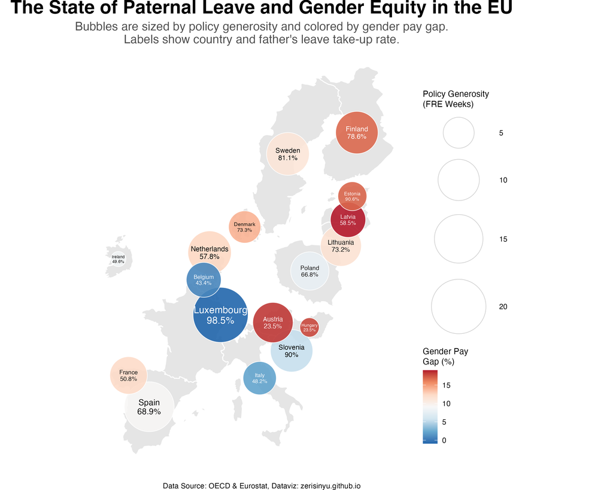

The State of Paternal Leave and Gender Equity in the EU

```r
# Load necessary libraries
library(tidyverse)
library(sf) # For working with spatial data
library(rnaturalearth) # For getting map data
library(rnaturalearthdata) # The map data itself
library(ggrepel) # For labels (optional for maps, but can be useful)

# --- Step 1: Prepare Your Data ---
# Assuming 'df_eu' is your final, cleaned dataframe for EU countries.
df_map_data <- df %>%
  mutate(Country = case_when(
    Country == "Czechia" ~ "Czech Republic",
    TRUE ~ Country
  )) %>%
  # Filter out countries that don't have all the data points we need for the bubbles
  filter(Father_Take_Up_Rate_pct > 0 & Fathers_FRE_Weeks_2023 > 0)


# --- Step 2: Get Map Data and Join ---
world_map <- ne_countries(scale = "medium", returnclass = "sf")

europe_map_data_joined <- world_map %>%
  right_join(df_map_data, by = c("name" = "Country"))

# --- Step 3: Calculate Centroids and Add Dynamic Text Color ---
# We define a threshold for the gender pay gap. Values within this range
# will get black text, values outside will get white text.
text_color_threshold_low <- 6
text_color_threshold_high <- 16

 dynamic_text_size = 1.5 + europe_map_data_joined$Fathers_FRE_Weeks_2023 / max(europe_map_data_joined$Fathers_FRE_Weeks_2023) * 2.5

country_offsets <- tribble(
  ~name,            ~x_offset, ~y_offset,
  "Belgium",        -0.5,       0.7,
  "Netherlands",     0,         1.5,
  "Luxembourg",      0.5,      -1.5,
  "Slovenia",        2.0,      -1.0,
  "Czech Republic",  2.0,       1.0,
  "Slovak Republic", 3.0,      -0.5,
  "Malta",           0,        -1.5,
  "Lithuania",       0,        -1.0,
  "Latvia",          0,        -0.25,
)

europe_map_data_joined <- europe_map_data_joined %>%
  mutate(
    centroid = st_centroid(geometry),
    centroid_x = st_coordinates(centroid)[,1],
    centroid_y = st_coordinates(centroid)[,2]
  ) %>%
  # Join our custom offsets
  left_join(country_offsets, by = "name") %>%
  # Replace NA offsets with 0 so we can add them
  mutate(
    x_offset = ifelse(is.na(x_offset), 0, x_offset),
    y_offset = ifelse(is.na(y_offset), 0, y_offset),
    # Add other mutations for text color and size
    text_color = ifelse(
      Gender_Pay_Gap_2023_pct > 5 & Gender_Pay_Gap_2023_pct < 16, "black", "white"
    ),
    dynamic_text_size = 1.5 + europe_map_data_joined$Fathers_FRE_Weeks_2023 / max(europe_map_data_joined$Fathers_FRE_Weeks_2023) * 2.5
  )



# --- Step 4: Create the Final Bubble Map ---
final_bubble_map_contrast <- ggplot(data = europe_map_data_joined) +
  # Layer 1: The base map
  geom_sf(fill = "grey90", color = "white", linewidth = 0.5) +

  # Layer 2: The bubbles (points)
  geom_point(
    aes(x = centroid_x + x_offset,
        y = centroid_y + y_offset,
        size = Fathers_FRE_Weeks_2023,
        fill = Gender_Pay_Gap_2023_pct),
    shape = 21,
    alpha = 0.9,
    stroke = 0.5,
    color = "white"
  ) +

  # --- REVISED: Layer 3 - Text with dynamic color mapping ---
  geom_text(
    aes(x = centroid_x + x_offset, y = centroid_y + y_offset,
        label = paste0(name, "\n", Father_Take_Up_Rate_pct, "%"),
        color = text_color), # Color is now an aesthetic mapped to our new column
    size = dynamic_text_size,
    lineheight = 0.9
  ) +

  # --- Step 5: Apply Scales and Aesthetics ---
  scale_fill_distiller(
    palette = "RdBu",
    direction = -1,
    name = "Gender Pay\nGap (%)"
  ) +

  scale_size(
    name = "Policy Generosity\n(FRE Weeks)",
    range = c(8, 30)
  ) +

 guides(
    size = guide_legend(override.aes = list(stroke = 0.5, color = "grey80"))
  ) +

  # --- NEW: Add scale_color_identity() ---
  # This tells ggplot to use the color names directly from the 'text_color' column.
  scale_color_identity() +

  coord_sf(xlim = c(-10, 35), ylim = c(35, 70), expand = FALSE) +

  labs(
    title = "The State of Paternal Leave and Gender Equity in the EU",
    subtitle = "Bubbles are sized by policy generosity and colored by gender pay gap.\nLabels show country and father's leave take-up rate.",
    caption = "Data Source: OECD & Eurostat, Dataviz: zerisinyu.github.io"
  ) +

  theme_void() +
  theme(
    plot.title = element_text(face = "bold", size = 22, hjust = 0.5, margin = margin(b = 5)),
    plot.subtitle = element_text(size = 14, color = "grey30", hjust = 0.5, margin = margin(b = 25)),
    plot.caption = element_text(hjust = 0.5, margin = margin(t = 20)),
    legend.position = "right",
    legend.spacing.y = unit(0.2, 'cm'),
    legend.title = element_text(size = 10, lineheight = 1.0),
    plot.background = element_rect(fill = "white", color = NA)
  )

# Save and print the final map
ggsave("final_map_high_contrast.png", plot = final_bubble_map_contrast, width = 10, height = 8, dpi = 300)
print(final_bubble_map_contrast)
```

1. **The Canvas: A Geographic Map.** A map was chosen for its ability to provide immediate geographic context.
2. **The Solution for Overlap: Manual Offsets.** To solve the inevitable problem of overlapping data points in dense geographic regions (e.g., the Benelux), custom x and y offsets were calculated and applied to the bubbles for those countries. This technique preserves relative geographic location while ensuring every data point is clearly visible, demonstrating an attention to detail beyond default settings.
3. **Layered Data Encoding:**
   - `Bubble Size = Policy Generosity (FRE Weeks)`: This provides an intuitive visual hierarchy where a more significant policy effort is represented by a larger bubble.
   - `Bubble Color = The Problem (Gender Pay Gap)`: To highlight the primary outcome variable, a “cool-to-hot” diverging palette (RdBu) was selected. Cool blue signals a low (positive) pay gap, while alarming red signals a high (problematic) one, immediately drawing the eye to areas of concern.
   - `The Text = The Outcome:` The text inside each bubble displays the two most important pieces of information: the country’s name and the father’s take-up rate.
   - `Final Polish: High-Contrast, Scaled Text.` To guarantee readability against the varied background colors of the bubbles, logic was implemented to render the text in white on dark-colored bubbles and black on light-colored bubbles. To create visual harmony, the font size was also scaled to be proportional to the bubble’s size.

# 4 Conclusion